# Diseño completamente aleatorizado con efectos aleatorios

Gerardo Martín

23/2/2021

# 1 Introducción

En la sección anterior vimos brevemente la diferencia entre efectos fijos y aleatorios:

- **Efectos fijos** Aquellos factores que estamos controlando y que sabemos que afectan el valor medio de la variable de respuesta.
- **Efectos aleatorios** Aquellos factores que no estamos controlando y que sabemos que pueden afectar la dispersión (varianza) de la variable de respuesta.

Otra catacterística de los **efectos aleatorios** es que no estamos interesados en determinar si alteran el valor o magnitud de la variable de respuesta. Es por estas razones que cuando incluimos efectos aleatorios en los análisis estadísticos, estamos tratando de identificar qué porción del error de la variable de respuesta de debe a los tratamientos y cuál a los bloques (¡recordemos que debemos incluir los efectos aleatorios solamente si estos existen en el diseño experimental!).

Como vimos en el tutorial de R, para hacer un ANOVA debemos de especificar la fórmula del modelo: `y ~ x`. Donde $y$ es la variable de respuesta y $x$ es la independiente con tantos niveles categóricos como decidamos incluir en el experimento. En ANOVA con efectos aleatorios también debemos especificarlos en la fórmula del modelo como: `y ~ x + Error(bloque)`, donde `bloque` debe ser una columna adicional dentro de la base de datos que especifica a qué bloque pertenece cada dato, y la función `Error` especifica que la variable `bloque` es un efecto aleatorio pues solamente afecta al **error** o variabilidad de $y$.

# 2 Análisis del diseño aleatorizado con efectos aleatorios

El diseño aleatorizado con efectos aleatorios, como su nombre lo dice, consiste de la asignación aleatoria de las unidades observacionales a los tratamientos y de estos a los bloques. Por lo tanto, es posible que haya bloques que consten solamente de una fracción de los tratamientos:

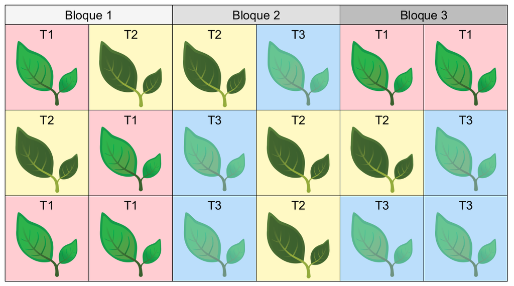

Figure 2.1: Esquema del diseño aleatorizado con bloques.

El primero problema con que nos encontramos es el desarrollo de un mecanismo para asginar de manera aleatoria, los tratamientos a los bloques y las unidades a los tratamientos y bloques. Esto puede ser hecho en **R** de manera sencilla.

Para el análisis estadístico sin embargo, es necesario tomar en cuenta los bloques para estimar los efectos aleatorios. Comenzaremos por simular una base de datos para un tratamiento con tres niveles en tres bloques, donde hay cinco unidades experimentales por tratamiento. Para poder dar seguimiento más fácil al código, aquí se asignan los tratamientos a los bloques de manera uniforme:

```r
t1.1 <- rnorm(5, mean = 5, sd = 5)
t1.2 <- rnorm(5, mean = 5, sd = 10)
t1.3 <- rnorm(5, mean = 5, sd = 3)

t2.1 <- rnorm(5, mean = 7, sd = 10)
t2.2 <- rnorm(5, mean = 7, sd = 12)
t2.3 <- rnorm(5, mean = 7, sd = 3)

t3.1 <- rnorm(5, mean = 5.5, sd = 3)
t3.2 <- rnorm(5, mean = 5.5, sd = 2)
t3.3 <- rnorm(5, mean = 5.5, sd = 4)

tratamientos <- rep(rep(c("A", "B", "C"), each = 5), 3)
bloques <- rep(c("a", "b", "c"), each = 15)
```

```r
base.datos <- data.frame(Valor = c(t1.1, t2.1, t3.1,
                                   t1.2, t2.2, t3.2,
                                   t1.3, t2.3, t3.3),
                         Tratamiento = tratamientos,
                         Bloque = bloques)
head(base.datos)
```

```
##       Valor Tratamiento Bloque
## 1  2.197622           A      a
## 2  3.849113           A      a
## 3 12.793542           A      a
## 4  5.352542           A      a
## 5  5.646439           A      a
## 6 24.869131           B      a
```

```r
tail(base.datos)
```

```
##         Valor Tratamiento Bloque
## 40 10.7614448           B      c
## 41  2.7211721           C      c
## 42  4.6683309           C      c
## 43  0.4384146           C      c
## 44 14.1758239           C      c
## 45 10.3318480           C      c
```

Como podemos ver, las medias de cada tratamiento fueron iguales, independientemente del bloque, y la desviación estándar de `valor` cambió entre bloques. Ahora hagamos el análisis de varianza con efectos aleatorios:

```r
modelo.1 <- aov(Valor ~ Tratamiento + Error(Bloque/Tratamiento), base.datos)
summary(modelo.1)
```

```
##
## Error: Bloque
##           Df Sum Sq Mean Sq F value Pr(>F)
## Residuals  2    155   77.51
##
## Error: Bloque:Tratamiento
##             Df Sum Sq Mean Sq F value Pr(>F)
## Tratamiento  2  33.75   16.87   0.475  0.653
## Residuals    4 142.12   35.53
##
## Error: Within
##           Df Sum Sq Mean Sq F value Pr(>F)
## Residuals 36   1685   46.81
```

Entonces, debido al error explicado por los tratamientos, la probabilidad de que estos tengan medias parecidas es muy alta $P = 0.653$, con lo que no podemos rechazar $H_0$ de no diferencias entre tratamientos. Veamos que pasa si omitimos los efectos aleatorios:

```r
modelo.2 <- aov(Valor ~ Tratamiento, base.datos)
summary(modelo.2)
```

```
##             Df Sum Sq Mean Sq F value Pr(>F)
## Tratamiento  2   33.7   16.87   0.358  0.702
## Residuals   42 1982.4   47.20
```

# 3 Aplicación del conocimiento

Completa la actividad correspondiente a este módulo en Classroom.

Regresar al índice del curso